# Modelaje Epidemiológico en `R`

# Funciones en `R`

Una función la podemos pensar como un pedazo de código que transforma un poco de código en otra cosa.

Una función toma ciertos valores de input y regresa ciertos outputs

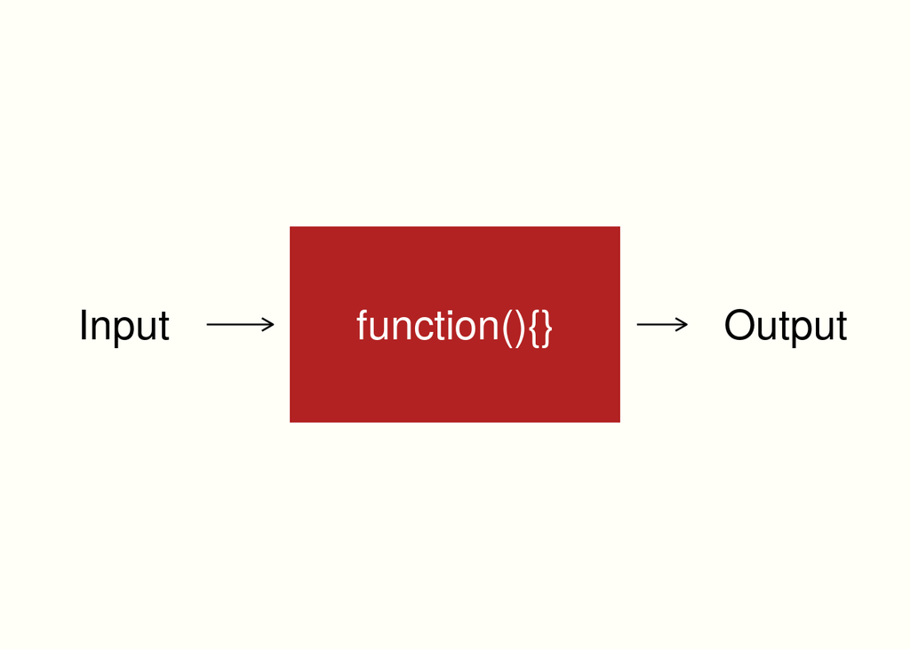

Por si te lo preguntabas, sí, también el diagrama lo hicimos con `ggplot2` ;)

Por ejemplo la siguiente función toma como `Input` un número y le suma `5` (yo sé que es una función muy inútil pero vamos paso a paso):

```r
#Defino mi función
suma.5 <- function(mi.numero){
  return(mi.numero + 5)
}

#Pruebo mi función
suma.5(10)
```

```
## [1] 15
```

```r
suma.5(1)
```

```
## [1] 6
```

```r
suma.5("Pingüino")
```

```
## Error in mi.numero + 5: non-numeric argument to binary operator
```

La estructura básica de una función en `R` es como sigue:
$$\begin{aligned}
\text{Nombre.de.la.function}& \leftarrow\textrm{function}(\overbrace{\textrm{Inputs}}^{\text{Lo que necesita para funcionar}})\{
\\
& \text{Código} \\
& \text{return}(\underbrace{\text{Output}}_{\textrm{Lo que resulta}})
\\
\}
\end{aligned}$$
Veamos otra función:

```r
#Función que dice ¡Hola ----! donde ---- es el nommbre que se mete
mi.saludo <- function(nombre){
  saludo <- paste0("¡Hola ", nombre, "!")
  return(saludo)
}

#Ejemplos
mi.saludo("Ana")
```

```
## [1] "¡Hola Ana!"
```

```r
mi.saludo("Jesús")
```

```
## [1] "¡Hola Jesús!"
```

Una función puede tener múltiples parámetros, por ejemplo la función que resta un número a otro:

```r
resta.numeros <- function(num.1, num.2){
  mi.resta <- num.1 - num.2
  return(mi.resta)
}

#Restamos dos números
resta.numeros(10, 3)
```

```
## [1] 7
```

```r
#Observa cómo el orden importa
resta.numeros(3, 10)
```

```
## [1] -7
```

En general las buenas prácticas de `R` te piden que utilices [el formato `roxygen2`](https://kbroman.org/pkg_primer/pages/docs.html) para documentar la función ¡lo mejor es siempre poner qué hace tu función pues la idea es reciclarla cuantas veces sea necesaria!

```r
resta.numeros <- function(num.1, num.2){
  #' resta.numeros
  #'
  #' Función que calcula num.1 - num.2
  #' @param num.1 Número que se va a restar
  #' @param num.2 Número que se resta de num.1
  #' @return num.1 - num.2

  mi.resta <- num.1 - num.2
  return(mi.resta)
}
```

En este caso, quizá no tiene mucho sentido documentar la función. Pero cuando uno trabaja con proyectos más grandes (o con más personas) ¡es bastante importante saber qué hace una función!

Por último, una función también puede regresar múltiples valores. Para ello está el comando `list`. Por ejemplo, la función que regresa la media y desviación estándar de un vector:

```r
media.y.varianza <- function(mi.vector){
  #' media.y.varianza
  #'
  #' Función que calcula la media y desviación estándar de un vector
  #' @param mi.vector Un vector de R al cual calcular media y desviación
  #' @return mi.lista Lista de parámetros que contiene:
  #'           media    Media del vector
  #'           desv.est Desviación estándar del mismo

  #Calculamos la media
  media    <- mean(mi.vector)

  #Calculamos la desviación estándar
  desv.est <- sd(mi.vector)

  return(list(promedio = media, desviacion = desv.est))
}

#Veamos un ejemplo:
un.vector <- c(0.27, -0.34, 0.11, -0.6, 0.82, -0.41)

#Podemos calcular ambas
media.y.varianza(un.vector)
```

```
## $promedio
## [1] -0.025
##
## $desviacion
## [1] 0.5286492
```

```r
#Para acceder a un valor hay que usar $
media.y.varianza(un.vector)$promedio
```

```
## [1] -0.025
```

donde `mean` es una función de `R` que calcula la media de un vector:

```r
#Cremos un vector
x <- c(1, 0.5, 2, 0.6, 0.4, 0, 0.2)
mean(x)
```

```
## [1] 0.6714286
```

y `sd` calcula su desviación estándar:

```r
sd(x)
```

```
## [1] 0.6651172
```

## Ejercicios

1. Construye una función que dada la altura (en metros) y peso (en kilogramos) de una persona, calcule su índice de masa corporal `IMC`. Recuerda que éste está dado por la fórmula:
   $$\text{IMC} = \dfrac{\text{Peso}}{(\text{Altura})^2}$$
2. Construye una función que se llame `grafica.linea` que dado una base de datos (`data.frame`) que contiene las variables `x` y `y` cree una gráfica de línea con `ggplot` de `x` contra `y`. Prueba que con los siguientes datos funcione como en los ejemplos:

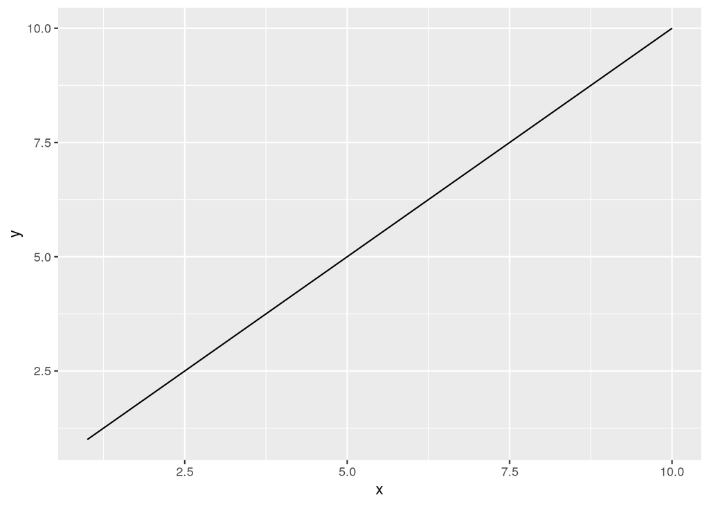

```r
#Primera base de datos
datos1 <- data.frame(x = 1:10, y = 1:10)
grafica.linea(datos1)
```

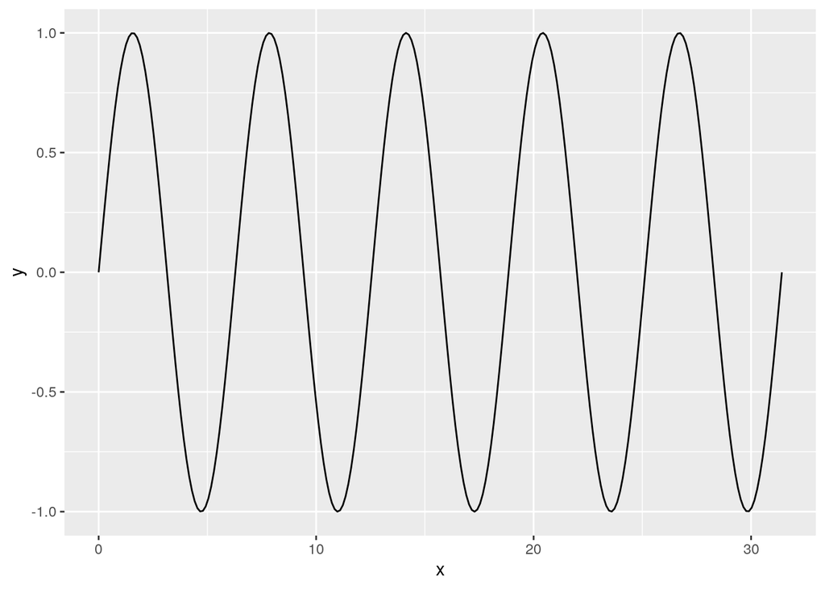

```r
#Segunda base de datos
x <- seq(0,10*pi, length.out = 250)
datos2 <- data.frame(x = x, y = sin(x))
grafica.linea(datos2)
```

3. Utiliza las funciones de `cos()`, `sin()` y `log()` para crear una única función que dado un número regrese su coseno, su seno y su logaritmo natural. El ‘output’ de la función debe ser algo así:

```r
#Así debe de correr:
ejercicio.3(12)
```

```
## $coseno
## [1] 0.843854
##
## $seno
## [1] -0.5365729
##
## $logaritmo
## [1] 2.484907
```

## De vuelta al análisis de bases

Armados con el concepto de función podemos abstraer lo que tienen en común las secciones de Sexo, Entidad y Causa del apartado anterior:

```r
#SEXO
#-----------------------------------------------------
mortalidad.2016.editada.v2 <- merge(mortalidad.2016.editada, dic.sexo,
                                 by.x = "Sexo", by.y = "CVE",
                                 all.x = TRUE, all.y = FALSE)

#Eliminamos la columna de sexo
mortalidad.2016.editada.v2 <- mortalidad.2016.editada.v2 %>%
                                  select(-c("Sexo"))

#Renombramos DESCRIP como Sexo
mortalidad.2016.editada.v2 <- mortalidad.2016.editada.v2 %>%
                                  rename("Sexo" = "DESCRIP")

#CAUSA
#-----------------------------------------------------
mortalidad.2016.editada.v2 <- merge(mortalidad.2016.editada.v2,
                                    dic.causa, by.x = "Causa",
                                    by.y = "CVE", all.x = TRUE,
                                    all.y = FALSE)

#Eliminamos la columna de edad
mortalidad.2016.editada.v2 <- mortalidad.2016.editada.v2 %>%
                                  select(-c("Causa"))

#Renombramos DESCRIP como Sexo
mortalidad.2016.editada.v2 <- mortalidad.2016.editada.v2 %>%
                                  rename("Causa" = "DESCRIP")

#ENTIDAD
#-----------------------------------------------------
mortalidad.2016.editada.v2 <- merge(mortalidad.2016.editada.v2,
                                    dic.entidad, by.x = "Entidad",
                                    by.y = "cve_ent", all.x = TRUE,
                                    all.y = FALSE)

#Eliminamos la columna de edad
mortalidad.2016.editada.v2 <- mortalidad.2016.editada.v2 %>%
                                  select(-c("Entidad"))

#Renombramos DESCRIP como Sexo
mortalidad.2016.editada.v2 <- mortalidad.2016.editada.v2 %>%
                                  rename("Entidad" = "nom_loc")
```

Nota que en todos los casos aparecen los mismos tres comandos. Podemos abstraerlos para generar una función:

```r
indicadores.mortalidad <- function(base.mortalidad, base.indicadores,
                                   indicador.x, indicador.y, nombre.y){

    #SEXO
    #-----------------------------------------------------
    nueva.base <- merge(base.mortalidad, base.indicadores,
                        by.x = indicador.x, by.y = indicador.y,
                        all.x = TRUE, all.y = FALSE)

    #Eliminamos la columna de sexo
    nueva.base <- nueva.base %>% select(-c(!!indicador.x))

    #Renombramos DESCRIP como Sexo
    nueva.base <- nueva.base %>% rename(!!indicador.x := nombre.y)

    return(nueva.base)

}
```

Veamos que funciona con lo que habíamos hecho para `2016`:

```r
# 1 Leemos la base
mortalidad.2016 <- read.csv(mi.base)

# 2 Elegimos sólo las variables que nos interesan
mortalidad.2016.editada <- mortalidad.2016 %>%
  select(c("ent_regis", "sexo", "edad",
           "dia_ocurr", "mes_ocurr", "anio_ocur", "causa_def"))

#Cambiamos los nombres de las variables
colnames(mortalidad.2016.editada) <- c("Entidad", "Sexo", "Edad",
                                       "Día", "Mes", "Año", "Causa")

#Aquí cambiamos lo de sexo
mortalidad.2016.editada.v2 <-
  indicadores.mortalidad(mortalidad.2016.editada, dic.sexo,
                         "Sexo", "CVE", "DESCRIP")

#Aquí cambiamos lo de causa
mortalidad.2016.editada.v2 <-
  indicadores.mortalidad(mortalidad.2016.editada.v2, dic.causa,
                         "Causa", "CVE", "DESCRIP")

#Aquí cambiamos lo de estado
mortalidad.2016.editada.v2 <-
  indicadores.mortalidad(mortalidad.2016.editada.v2, dic.entidad,
                         "Entidad", "cve_ent", "nom_loc")

# 4 Filtramos
mortalidad.miocardio <- mortalidad.2016.editada.v2 %>%
  filter(Causa %in% causas.miocardio) %>%
  count(Sexo, Mes, Entidad)

# 5 Agregaré una columna a la base que se llame año con 2016
mortalidad.miocardio[, "Año"] <- 2016

# Renombraremos la columna n como defunciones
mortalidad.miocardio.2016 <- mortalidad.miocardio %>%
  rename("Defunciones" = "n")
```

¿Será que podemos abstraer aún más esta función? ¡Por supuesto! Vamos a crear una función que nos permita leer las bases de datos para cada uno de los años de tal manera que podamos hacer el análisis mucho más rápido.

```r
analisis.mortalidad <- function(base, anio, causas){

  # 1 Leemos la base
  mortalidad <- read.csv(base)

  # 2 Elegimos sólo las variables que nos interesan
  mortalidad <- mortalidad %>%
    select(c("ent_regis", "sexo", "edad",
             "dia_ocurr", "mes_ocurr", "anio_ocur", "causa_def"))

  #Cambiamos los nombres de las variables
  colnames(mortalidad) <- c("Entidad", "Sexo", "Edad",
                                         "Día", "Mes", "Año", "Causa")

  #Aquí cambiamos lo de sexo
  mortalidad <-
    indicadores.mortalidad(mortalidad, dic.sexo,
                           "Sexo", "CVE", "DESCRIP")

  #Aquí cambiamos lo de causa
  mortalidad <-
    indicadores.mortalidad(mortalidad, dic.causa,
                           "Causa", "CVE", "DESCRIP")

  #Aquí cambiamos lo de estado
  mortalidad <-
    indicadores.mortalidad(mortalidad, dic.entidad,
                           "Entidad", "cve_ent", "nom_loc")

  # 4 Filtramos
  mortalidad.causas <- mortalidad %>%
    filter(Causa %in% !!causas) %>%
    count(Sexo, Mes, Entidad, Día)

  # 5 Agregaré una columna a la base que se llame año con 2016
  mortalidad.causas[, "Año"] <- anio

  # Renombraremos la columna n como defunciones
  mortalidad.causas <- mortalidad.causas %>%
    rename("Defunciones" = "n")

  return(mortalidad.causas)
}
```

```r
datos.2016 <- "conjunto_de_datos_defunciones_generales_2016.CSV"
```

Veamos que sí sirve:

```r
base.2016 <- analisis.mortalidad(datos.2016, 2016, causas.miocardio)
```

Podemos, fácilmente, hacer los análisis para el resto de los años usando estas funciones:

```r
datos.2017 <- "conjunto_de_datos_defunciones_generales_2017.CSV"
datos.2015 <- "conjunto_de_datos_defunciones_generales_2015.CSV"
datos.2014 <- "conjunto_de_datos_defunciones_generales_2014.CSV"
datos.2013 <- "conjunto_de_datos_defunciones_generales_2013.CSV"
datos.2012 <- "conjunto_de_datos_defunciones_generales_2012.CSV"
```

```r
base.2017 <- analisis.mortalidad(datos.2017, 2017,
                                 causas.miocardio)
base.2015 <- analisis.mortalidad(datos.2015, 2015,
                                 causas.miocardio)
base.2014 <- analisis.mortalidad(datos.2014, 2014,
                                 causas.miocardio)
base.2013 <- analisis.mortalidad(datos.2013, 2013,
                                 causas.miocardio)
base.2012 <- analisis.mortalidad(datos.2012, 2012,
                                 causas.miocardio)
```

Finalmente, podemos juntar todos los datos en una sola base que contenga todos los años usando `bind_rows`:

```r
mortalidad <- base.2017 %>%
   bind_rows(base.2016) %>%
   bind_rows(base.2015) %>%
   bind_rows(base.2014) %>%
   bind_rows(base.2013) %>%
   bind_rows(base.2012)
```

Sobre esta base, podemos hacer mas análisis, por ejemplo, analizar las muertes totales por año:

```r
mortalidad %>%
  group_by(Año) %>%
  summarise(Defunciones = sum(Defunciones))
```

O bien graficar la evolución de las muertes totales por año, mes y sexo. Para ello usaremos pegamos la fecha y usamos `as.Date`:

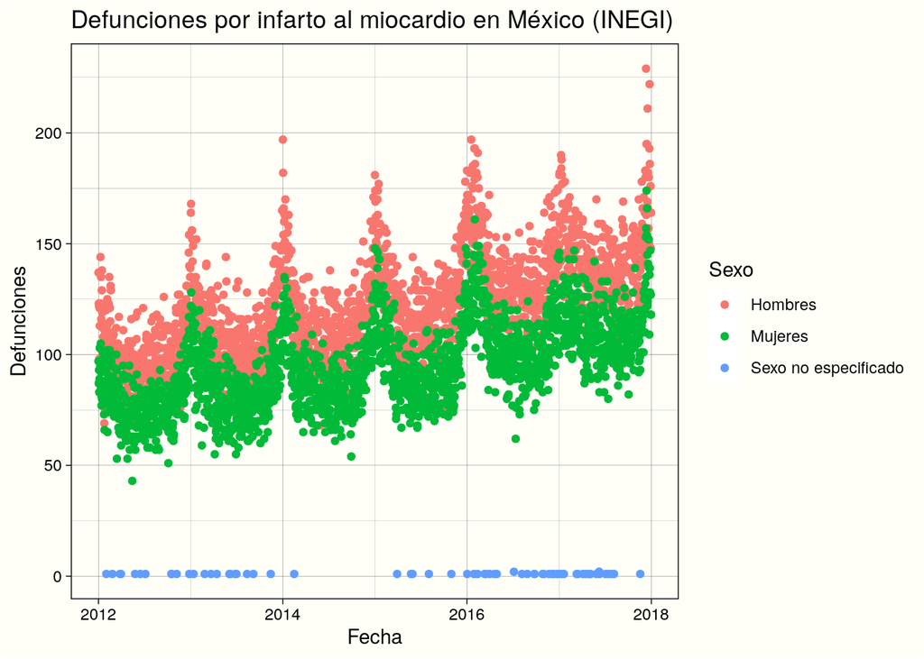

```r
#Eliminamos los registros que no tienen fecha
mortalidad.con.fecha <- mortalidad %>%
  filter(Mes < 13 & Día < 32)

#Hacemos que R sepa que estamos hablando de una fecha
mortalidad.con.fecha$Fecha <-as.Date(paste(mortalidad.con.fecha$Año,
                                        mortalidad.con.fecha$Mes,
                                        mortalidad.con.fecha$Día,
                                        sep = "-"))

#Eliminamos aquellos que quedaron sin fecha
mortalidad.con.fecha <- mortalidad.con.fecha %>%
  filter(!is.na(Fecha))

#Creamos la base agrupada por fecha y sexo
mortalidad.plot <- mortalidad.con.fecha %>%
  group_by(Sexo, Fecha) %>%
  summarise(Defunciones = sum(Defunciones))

#Graficamos
ggplot(mortalidad.plot) +
  geom_point(aes(x = Fecha, y = Defunciones, color = Sexo)) +
  theme_linedraw() +
  theme(plot.background = element_rect(fill = "#fffff8"),
        panel.background = element_rect(fill = "#fffff8"),
        legend.background = element_rect(fill = "#fffff8")) +
  ggtitle("Defunciones por infarto al miocardio en México (INEGI)")
```

O ajustar un modelo `Loess` que nos describa la mortalidad por mes y año gráficamente:

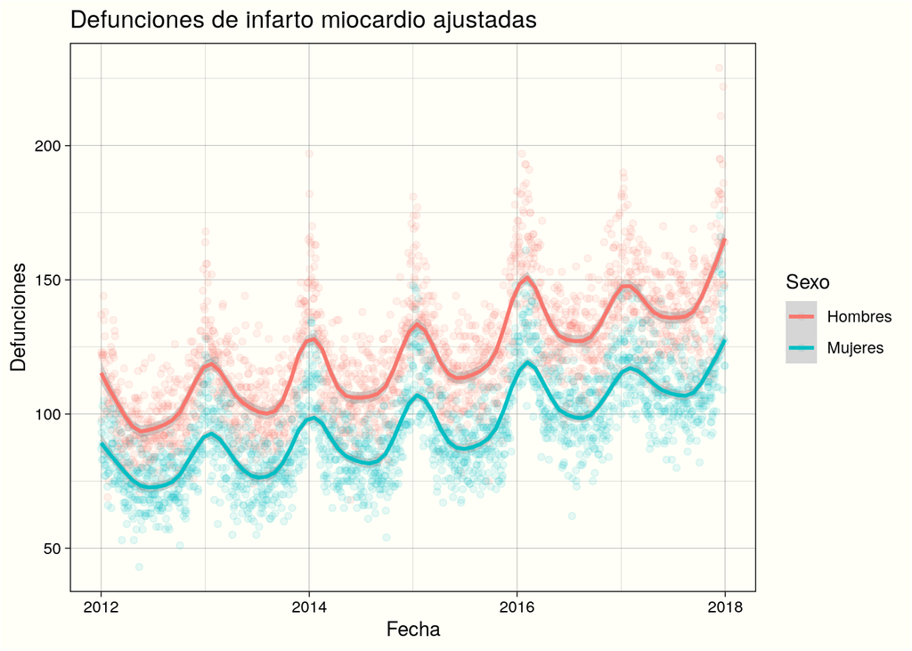

```r
#Eliminaremos a las personas de `Sexo no especificado` pues no
#es fácil describirlas (pocas mediciones relativamente):

#Creamos la base agrupada por fecha y sexo sin no especificado
mortalidad.plot <- mortalidad.plot %>%
  filter(Sexo != "Sexo no especificado")

#Agregamos el loess
ggplot(mortalidad.plot) +
  geom_point(aes(x = Fecha, y = Defunciones, color = Sexo),
              alpha = 0.1) +
  geom_smooth(aes(x = Fecha, y = Defunciones, color = Sexo),
              method = "loess", span = 0.1,
              method.args = list(degree = 1)) +
  ggtitle("Defunciones de infarto miocardio ajustadas") +
  theme_linedraw() +
  theme(plot.background   = element_rect(fill = "#fffff8"),
        panel.background  = element_rect(fill = "#fffff8"),
        legend.background = element_rect(fill = "#fffff8"))
```

Finalmente, podemos utilizar la función `summarise` para obtener estadísticas descriptivas como pueden ser la media `mean`, varianza `var`, cuantiles `quantile`, mínimo `min`, máximo `max`, mediana `median` de defunciones por año y sexo:

```r
#Generamos la base de datos
resumen.mortalidad <-
        mortalidad.con.fecha %>%
          group_by(Año, Sexo) %>%
          summarise(Promedio  = mean(Defunciones),
                    Varianza  = var(Defunciones),
                    Cuantil75 = quantile(Defunciones, 0.75),
                    Mínimo    = min(Defunciones),
                    Máximo    = max(Defunciones),
                    Mediana   = median(Defunciones))
```

Así obtenemos la siguiente tabla:

| Año | Sexo | Promedio | Varianza | Cuantil75 | Mínimo | Máximo | Mediana |
| --- | --- | --- | --- | --- | --- | --- | --- |
| 2012 | Hombres | 3.786345 | 9.992030 | 5 | 1 | 25 | 3 |
| 2012 | Mujeres | 3.301106 | 8.975015 | 4 | 1 | 28 | 2 |
| 2012 | Sexo no especificado | 1.000000 | 0.000000 | 1 | 1 | 1 | 1 |
| 2013 | Hombres | 4.058740 | 11.505108 | 5 | 1 | 27 | 3 |
| 2013 | Mujeres | 3.460832 | 9.530942 | 4 | 1 | 24 | 2 |
| 2013 | Sexo no especificado | 1.000000 | 0.000000 | 1 | 1 | 1 | 1 |
| 2014 | Hombres | 4.205994 | 12.412800 | 5 | 1 | 28 | 3 |
| 2014 | Mujeres | 3.574806 | 10.398984 | 4 | 1 | 26 | 3 |
| 2014 | Sexo no especificado | 1.000000 | NA | 1 | 1 | 1 | 1 |
| 2015 | Hombres | 4.432604 | 13.583240 | 6 | 1 | 27 | 3 |
| 2015 | Mujeres | 3.763781 | 11.999110 | 5 | 1 | 28 | 3 |
| 2015 | Sexo no especificado | 1.000000 | 0.000000 | 1 | 1 | 1 | 1 |
| 2016 | Hombres | 4.857295 | 17.568506 | 6 | 1 | 32 | 4 |
| 2016 | Mujeres | 4.095724 | 14.836622 | 5 | 1 | 30 | 3 |
| 2016 | Sexo no especificado | 1.000000 | 0.000000 | 1 | 1 | 1 | 1 |
| 2017 | Hombres | 4.998373 | 17.508660 | 7 | 1 | 30 | 4 |
| 2017 | Mujeres | 4.249974 | 14.918720 | 5 | 1 | 30 | 3 |
| 2017 | Sexo no especificado | 1.000000 | 0.000000 | 1 | 1 | 1 | 1 |

Finalmente guardamos la base de datos ya sea en un `RDS` (formato de base de datos de `R`) ó en un `csv` para leerlo con nuestro programa favorito (Excel, Stata, SPSS, etc).

```r
#Lee con readRDS
saveRDS(mortalidad.con.fecha,
        file = "MortalidadMiocardio.rds" )

#Lee con Excel
write.csv(mortalidad.con.fecha,
          file = "MortalidadMiocardio.csv")
```

## Ejercicio

Describe la mortalidad por tus causas favoritas (NO enfermedad miocardio, *ej* `diabetes`, `cólera`, `tumor`) en México durante los años 2012 a 2017 y realiza una gráfica de la evolución de la enfermedad por sexo y por estado. ¿Qué puedes concluir? ¿Cuál es el mínimo mensual por sexo?¿Y la varianza por estado? ¿Cómo se ven los cuartiles `quartiles` por año? ¿En qué entidad federativa hubo la mayor cantidad de defunciones por dicha causa en el periodo `2013-2016`?